# Unsupervised Learning with R

# 5.Exploratory Data Analysis

## Univariate Analysis

### 1.Measures of Central Tendency & Measures of Dispersion

```r
# mean, median, Min, Max
summary(df_new)
```

```
##  Administrative  Administrative_Duration Informational
##  Min.   : 0.00   Min.   :  -1.00         Min.   : 0.0000
##  1st Qu.: 0.00   1st Qu.:   0.00         1st Qu.: 0.0000
##  Median : 1.00   Median :   9.00         Median : 0.0000
##  Mean   : 2.34   Mean   :  81.68         Mean   : 0.5088
##  3rd Qu.: 4.00   3rd Qu.:  94.75         3rd Qu.: 0.0000
##  Max.   :27.00   Max.   :3398.75         Max.   :24.0000
##  Informational_Duration ProductRelated   ProductRelated_Duration
##  Min.   :  -1.00        Min.   :  0.00   Min.   :   -1.0
##  1st Qu.:   0.00        1st Qu.:  8.00   1st Qu.:  193.6
##  Median :   0.00        Median : 18.00   Median :  609.5
##  Mean   :  34.84        Mean   : 32.06   Mean   : 1207.5
##  3rd Qu.:   0.00        3rd Qu.: 38.00   3rd Qu.: 1477.6
##  Max.   :2549.38        Max.   :705.00   Max.   :63973.5
##   BounceRates        ExitRates         PageValues        SpecialDay
##  Min.   :0.00000   Min.   :0.00000   Min.   :  0.000   Min.   :0.00000
##  1st Qu.:0.00000   1st Qu.:0.01422   1st Qu.:  0.000   1st Qu.:0.00000
##  Median :0.00293   Median :0.02500   Median :  0.000   Median :0.00000
##  Mean   :0.02045   Mean   :0.04150   Mean   :  5.952   Mean   :0.06197
##  3rd Qu.:0.01667   3rd Qu.:0.04848   3rd Qu.:  0.000   3rd Qu.:0.00000
##  Max.   :0.20000   Max.   :0.20000   Max.   :361.764   Max.   :1.00000
##     Month           OperatingSystems    Browser           Region
##  Length:12199       Min.   :1.000    Min.   : 1.000   Min.   :1.000
##  Class :character   1st Qu.:2.000    1st Qu.: 2.000   1st Qu.:1.000
##  Mode  :character   Median :2.000    Median : 2.000   Median :3.000
##                     Mean   :2.124    Mean   : 2.358   Mean   :3.153
##                     3rd Qu.:3.000    3rd Qu.: 2.000   3rd Qu.:4.000
##                     Max.   :8.000    Max.   :13.000   Max.   :9.000
##   TrafficType     VisitorType         Weekend         Revenue
##  Min.   : 1.000   Length:12199       Mode :logical   Mode :logical
##  1st Qu.: 2.000   Class :character   FALSE:9343      FALSE:10291
##  Median : 2.000   Mode  :character   TRUE :2856      TRUE :1908
##  Mean   : 4.075
##  3rd Qu.: 4.000
##  Max.   :20.000
```

```r
library(moments)
# mode function
getmode <- function(v) {
   uniqv <- unique(v)
   uniqv[which.max(tabulate(match(v, uniqv)))]
}
```

```r
#mean
mean(df_new$Administrative)
```

```
## [1] 2.340028
```

```r
#meadian
median(df_new$Administrative)
```

```
## [1] 1
```

```r
#mode
getmode(df_new$Administrative)
```

```
## [1] 0
```

```r
#variance
var(df_new$Administrative)
```

```
## [1] 11.09457
```

```r
#standard deviation
sd(df_new$Administrative)
```

```
## [1] 3.330851
```

```r
#variance
var(df_new$Administrative)
```

```
## [1] 11.09457
```

```r
#skewness
skewness(df_new$Administrative)
```

```
## [1] 1.946248
```

```r
#kurtosis
kurtosis(df_new$Administrative)
```

```
## [1] 7.636106
```

Administrative had a positive kurtosis.Showing the presence of outliers.

## Administrative Duration

```r
#mean
mean(df_new$Administrative_Duration)
```

```
## [1] 81.68214
```

```r
#median
median(df_new$Administrative_Duration)
```

```
## [1] 9
```

```r
#mode
getmode(df_new$Administrative_Duration)
```

```
## [1] 0
```

```r
#variance
var(df_new$Administrative_Duration)
```

```
## [1] 31516.25
```

```r
#standard deviation
sd(df_new$Administrative_Duration)
```

```
## [1] 177.5282
```

```r
#variance
var(df_new$Administrative_Duration)
```

```
## [1] 31516.25
```

```r
#skewness
skewness(df_new$Administrative_Duration)
```

```
## [1] 5.59021
```

```r
#kurtosis
kurtosis(df_new$Administrative_Duration)
```

```
## [1] 53.09389
```

## Informational

```r
#mean
mean(df_new$Informational)
```

```
## [1] 0.5088122
```

```r
#median
median(df_new$Informational)
```

```
## [1] 0
```

```r
#mode
getmode(df_new$Informational)
```

```
## [1] 0
```

```r
#variance
var(df_new$Informational)
```

```
## [1] 1.62771
```

```r
#standard deviation
sd(df_new$Informational)
```

```
## [1] 1.275817
```

```r
#variance
var(df_new$Informational)
```

```
## [1] 1.62771
```

```r
#skewness
skewness(df_new$Informational)
```

```
## [1] 4.013451
```

```r
#kurtosis
kurtosis(df_new$Informational)
```

```
## [1] 29.64254
```

## Informational Duration

```r
#mean
mean(df_new$Informational_Duration)
```

```
## [1] 34.83734
```

```r
#median
median(df_new$Informational_Duration)
```

```
## [1] 0
```

```r
#mode
getmode(df_new$Informational_Duration)
```

```
## [1] 0
```

```r
#variance
var(df_new$Informational_Duration)
```

```
## [1] 20010.51
```

```r
#standard deviation
sd(df_new$Informational_Duration)
```

```
## [1] 141.4585
```

```r
#variance
var(df_new$Informational_Duration)
```

```
## [1] 20010.51
```

```r
#skewness
skewness(df_new$Informational_Duration)
```

```
## [1] 7.537435
```

```r
#kurtosis
kurtosis(df_new$Informational_Duration)
```

```
## [1] 78.46409
```

## Product Related

```r
#mean
mean(df_new$ProductRelated)
```

```
## [1] 32.05845
```

```r
#median
median(df_new$ProductRelated)
```

```
## [1] 18
```

```r
#mode
getmode(df_new$ProductRelated)
```

```
## [1] 1
```

```r
#variance
var(df_new$ProductRelated)
```

```
## [1] 1989.241
```

```r
#standard deviation
sd(df_new$ProductRelated)
```

```
## [1] 44.60091
```

```r
#variance
var(df_new$ProductRelated)
```

```
## [1] 1989.241
```

```r
#skewness
skewness(df_new$ProductRelated)
```

```
## [1] 4.332134
```

```r
#kurtosis
kurtosis(df_new$ProductRelated)
```

```
## [1] 34.04903
```

## Product Related Duration

```r
#mean
mean(df_new$ProductRelated_Duration)
```

```
## [1] 1207.508
```

```r
#median
median(df_new$ProductRelated_Duration)
```

```
## [1] 609.5417
```

```r
#mode
getmode(df_new$ProductRelated_Duration)
```

```
## [1] 0
```

```r
#variance
var(df_new$ProductRelated_Duration)
```

```
## [1] 3686121
```

```r
#standard deviation
sd(df_new$ProductRelated_Duration)
```

```
## [1] 1919.927
```

```r
#variance
var(df_new$ProductRelated_Duration)
```

```
## [1] 3686121
```

```r
#skewness
#skewness(df_new$ProductRelated_Duration)
```

```r
#kurtosis
#kurtosis(df_new$ProductRelated_Duration)
```

## Bonus Rates

```r
#mean
mean(df_new$BounceRates)
```

```
## [1] 0.02044674
```

```r
#median
median(df_new$BounceRates)
```

```
## [1] 0.002930403
```

```r
#mode
getmode(df_new$BounceRates)
```

```
## [1] 0
```

```r
#variance
var(df_new$BounceRates)
```

```
## [1] 0.002061387
```

```r
#standard deviation
sd(df_new$BounceRates)
```

```
## [1] 0.0454025
```

```r
#variance
var(df_new$BounceRates)
```

```
## [1] 0.002061387
```

```r
#skewness
#skewness(df_new$BounceRates)
```

```r
#kurtosis
#kurtosis(df_new$BounceRates)
```

## Exit Rates

```r
#mean
mean(df_new$ExitRates)
```

```
## [1] 0.04149678
```

```r
#median
median(df_new$ExitRates)
```

```
## [1] 0.025
```

```r
#mode
getmode(df_new$ExitRates)
```

```
## [1] 0.2
```

```r
#variance
var(df_new$ExitRates)
```

```
## [1] 0.0021388
```

```r
#standard deviation
sd(df_new$ExitRates)
```

```
## [1] 0.04624716
```

```r
#variance
var(df_new$ExitRates)
```

```
## [1] 0.0021388
```

```r
#skewness
skewness(df_new$ExitRates)
```

```
## [1] 2.233125
```

```r
#kurtosis
kurtosis(df_new$ExitRates)
```

```
## [1] 7.624252
```

## Page Values

```r
#mean
mean(df_new$PageValues)
```

```
## [1] 5.9525
```

```r
#median
median(df_new$PageValues)
```

```
## [1] 0
```

```r
#mode
getmode(df_new$PageValues)
```

```
## [1] 0
```

```r
#variance
var(df_new$PageValues)
```

```
## [1] 348.1132
```

```r
#standard deviation
sd(df_new$PageValues)
```

```
## [1] 18.65779
```

```r
#variance
var(df_new$PageValues)
```

```
## [1] 348.1132
```

```r
#skewness
#skewness(df_new$PageValues)
```

```r
#kurtosis
kurtosis(df_new$PageValues)
```

```
## [1] 67.94031
```

## Special Day

```r
#mean
mean(df_new$SpecialDay)
```

```
## [1] 0.06197229
```

```r
#meadian
median(df_new$SpecialDay)
```

```
## [1] 0
```

```r
#mode
getmode(df_new$SpecialDay)
```

```
## [1] 0
```

```r
#variance
var(df_new$SpecialDay)
```

```
## [1] 0.03988432
```

```r
#standard deviation
sd(df_new$SpecialDay)
```

```
## [1] 0.1997106
```

```r
#variance
var(df_new$SpecialDay)
```

```
## [1] 0.03988432
```

```r
#skewness
skewness(df_new$SpecialDay)
```

```
## [1] 3.284481
```

```r
#kurtosis
kurtosis(df_new$SpecialDay)
```

```
## [1] 12.78605
```

## Operating Systems

```r
#mean
mean(df_new$OperatingSystems)
```

```
## [1] 2.124354
```

```r
#meadian
median(df_new$OperatingSystems)
```

```
## [1] 2
```

```r
#mode
getmode(df_new$OperatingSystems)
```

```
## [1] 2
```

```r
#variance
var(df_new$OperatingSystems)
```

```
## [1] 0.8226229
```

```r
#standard deviation
sd(df_new$OperatingSystems)
```

```
## [1] 0.9069856
```

```r
#variance
var(df_new$OperatingSystems)
```

```
## [1] 0.8226229
```

```r
#skewness
skewness(df_new$OperatingSystems)
```

```
## [1] 2.031955
```

```r
#kurtosis
kurtosis(df_new$OperatingSystems)
```

```
## [1] 13.26887
```

## Browser

```r
#mean
mean(df_new$Browser)
```

```
## [1] 2.358144
```

```r
#median
median(df_new$Browser)
```

```
## [1] 2
```

```r
#mode
getmode(df_new$Browser)
```

```
## [1] 2
```

```r
#variance
var(df_new$Browser)
```

```
## [1] 2.926075
```

```r
#standard deviation
sd(df_new$Browser)
```

```
## [1] 1.710578
```

```r
#variance
var(df_new$Browser)
```

```
## [1] 2.926075
```

```r
#skewness
skewness(df_new$Browser)
```

```
## [1] 3.215653
```

```r
#kurtosis
kurtosis(df_new$Browser)
```

```
## [1] 15.53659
```

All the variables were positively skewed and had a positive kurtosis indicating the presence of outliers.

### Univariate Graphical

#### Histogram

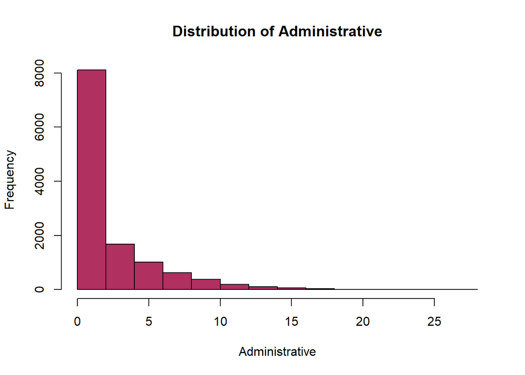

```r
hist(df_new$Administrative,main = "Distribution of Administrative",col="maroon",
     xlab="Administrative")
```

Administrative is positively skewed.

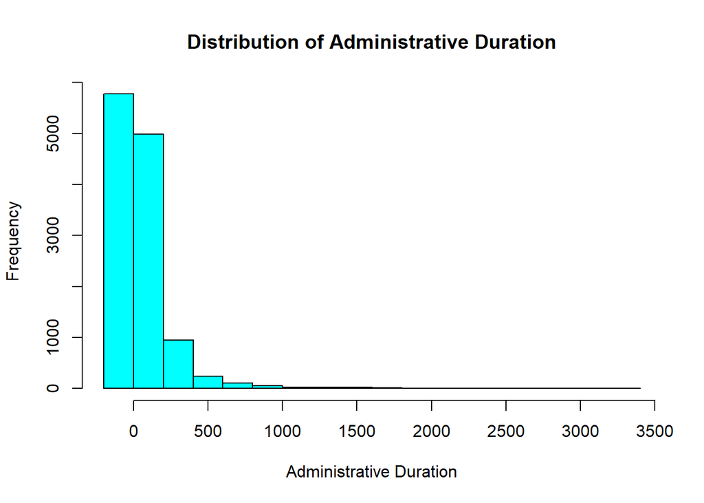

```r
hist(df_new$Administrative_Duration,main = "Distribution of Administrative Duration",col="cyan",
     xlab="Administrative Duration")
```

Administrative Duration is positively skewed.

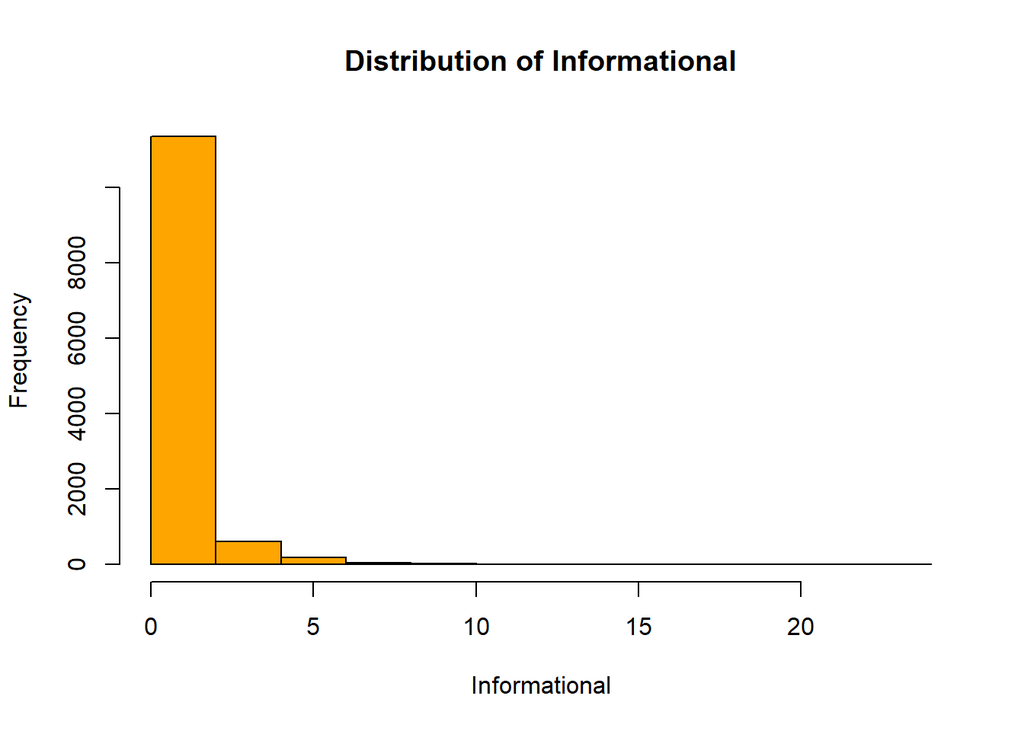

```r
hist(df_new$Informational,main = "Distribution of Informational",col="orange",
     xlab="Informational")
```

Informational is positively skewed.

Most of the values were 0.

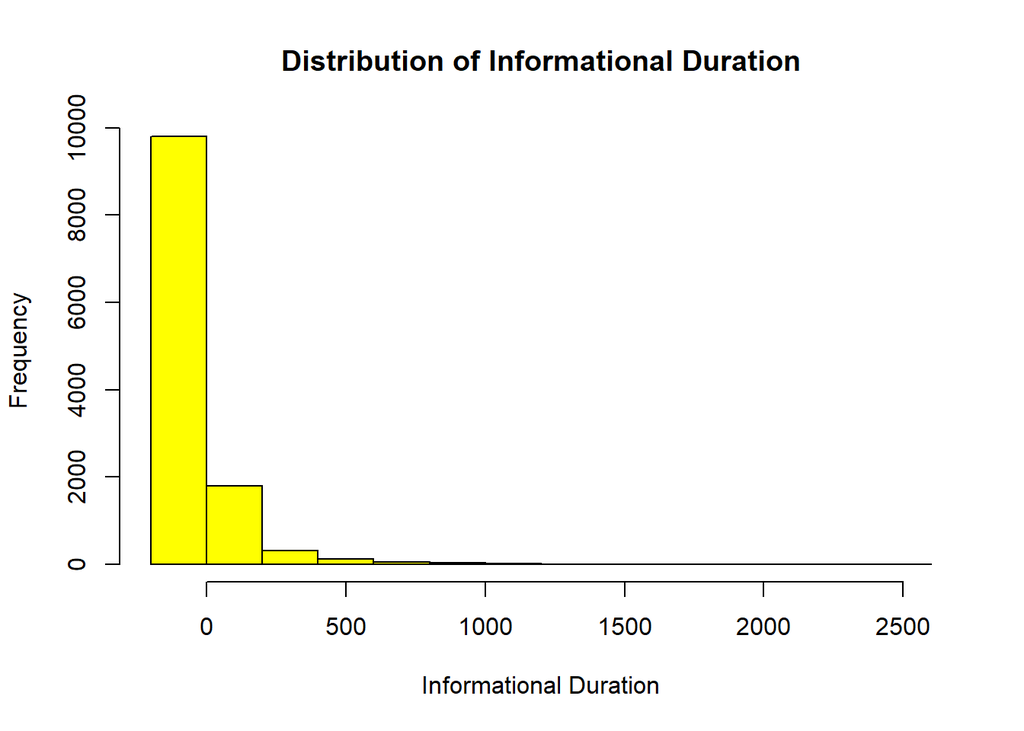

```r
hist(df_new$Informational_Duration,main = "Distribution of Informational Duration",col="yellow",
     xlab="Informational Duration")
```

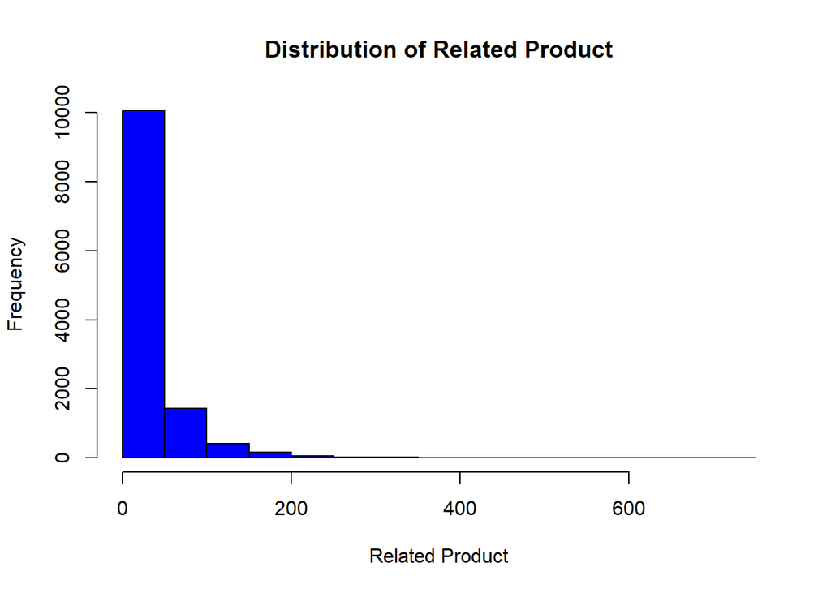

```r
hist(df_new$ProductRelated,main = "Distribution of Related Product",col="blue",
     xlab="Related Product")
```

[figure not shown]

```r
hist(df_new$ProductRelated_Duration,main = "Distribution of ",col="maroon",
     xlab="Administrative")
```

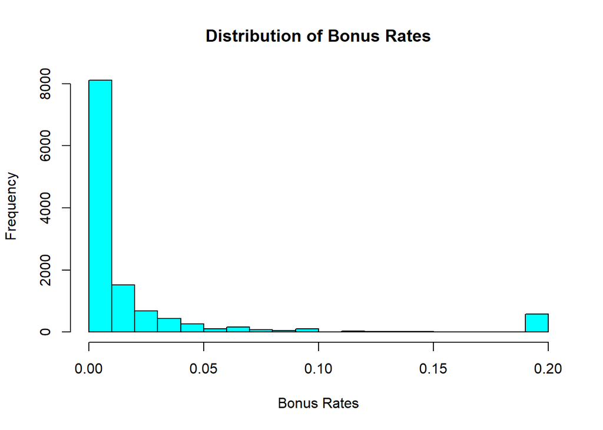

```r
hist(df_new$BounceRates,main = "Distribution of Bonus Rates",col="cyan",
     xlab="Bonus Rates")
```

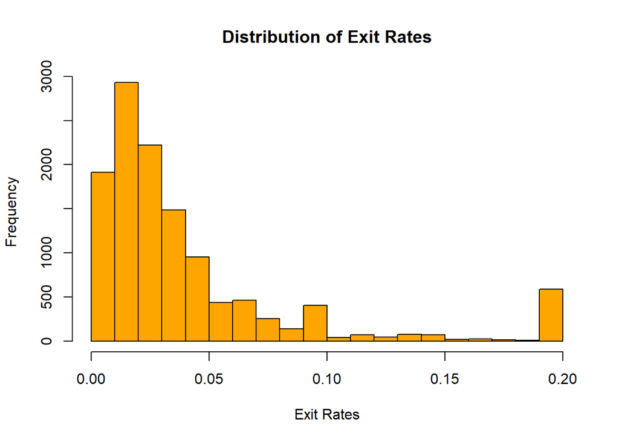

```r
hist(df_new$ExitRates,main = "Distribution of Exit Rates",col="orange",
     xlab="Exit Rates")
```

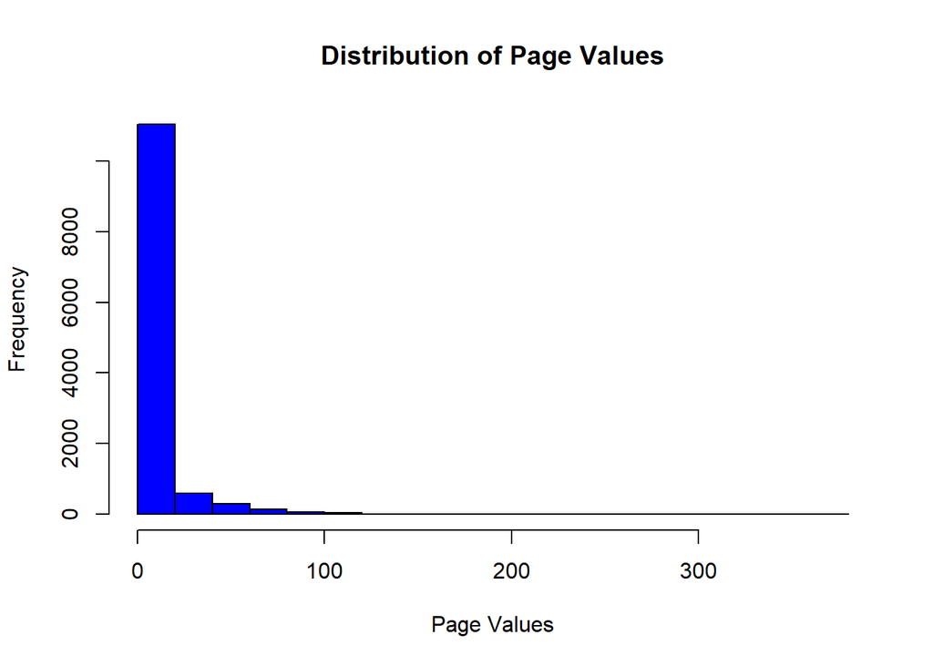

```r
hist(df_new$PageValues,main = "Distribution of Page Values",col="blue",
     xlab="Page Values")
```

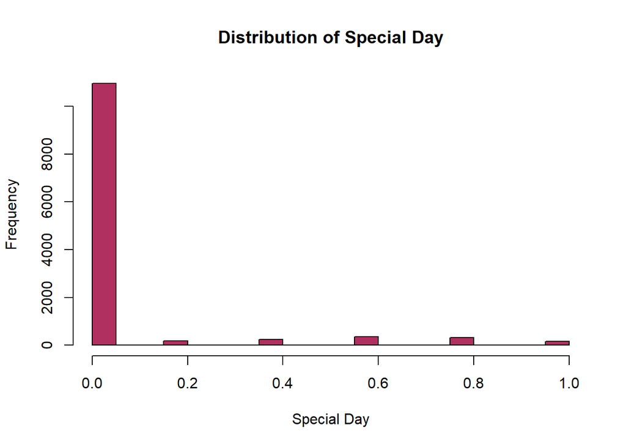

```r
hist(df_new$SpecialDay,main = "Distribution of Special Day",col="maroon",
     xlab="Special Day")
```

MOst of the values oin the Special Day column were 0.

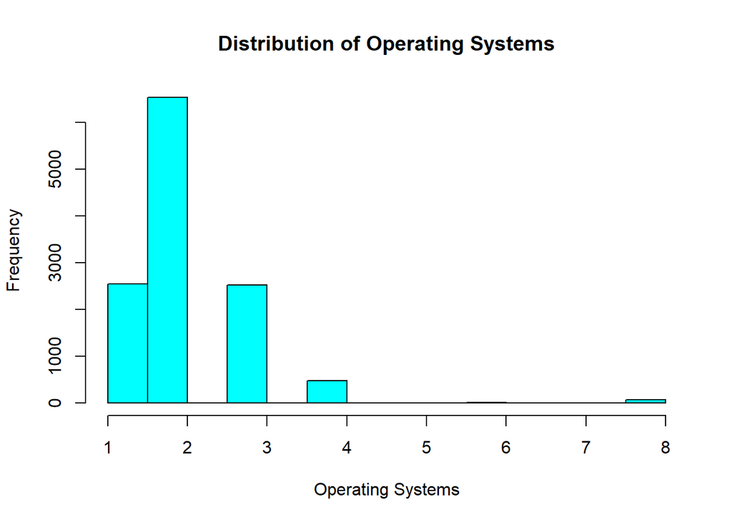

```r
hist(df_new$OperatingSystems,main = "Distribution of Operating Systems",col="cyan",
     xlab="Operating Systems")
```

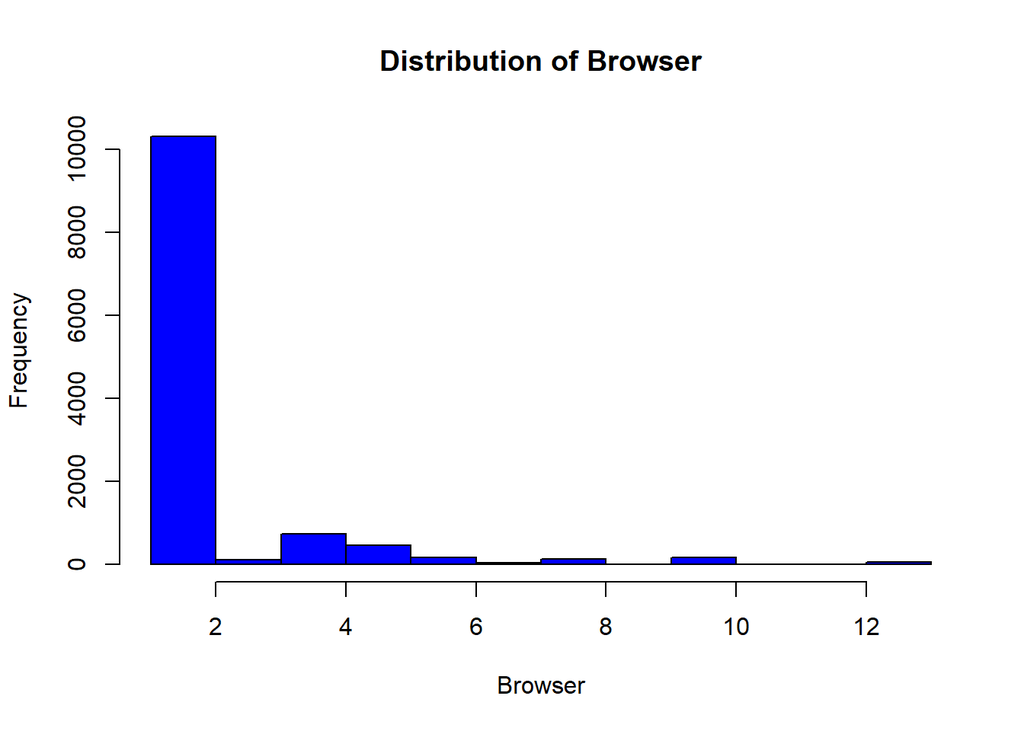

```r
hist(df_new$Browser,main = "Distribution of Browser",col="blue",
     xlab="Browser")
```

### Bar Chart

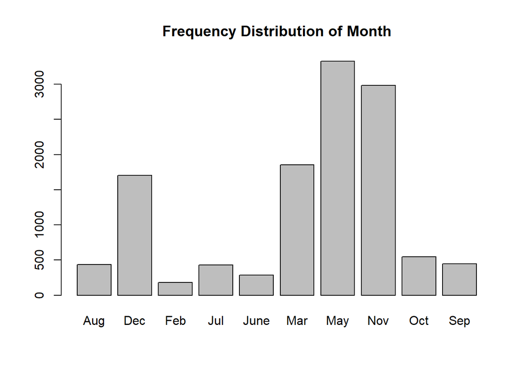

```r
#Month
frequency<-table(df_new$Month)
barplot(frequency,main = "Frequency Distribution of Month")
```

The Month of May had the highest number of records.

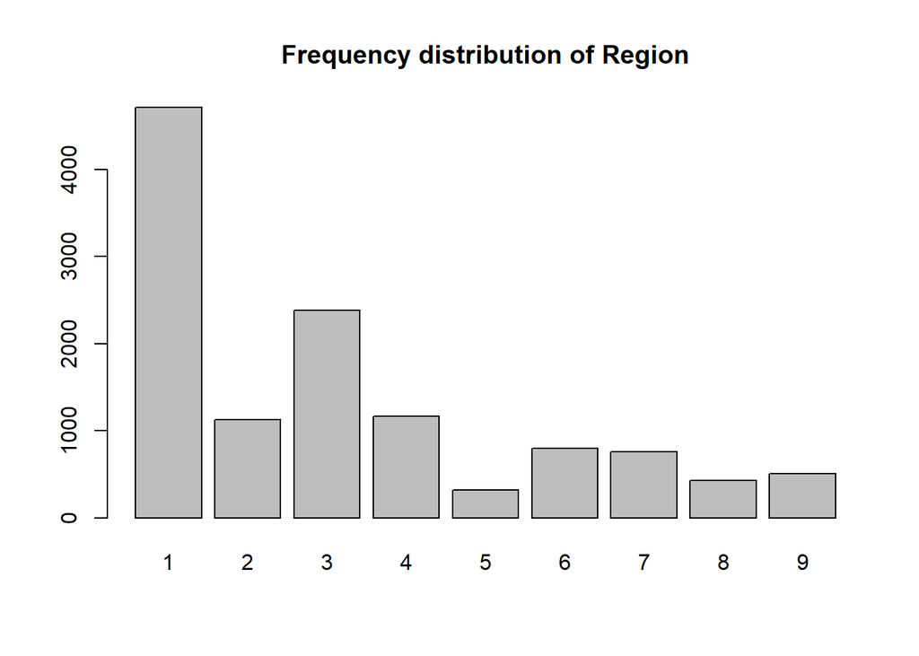

```r
frequency_region<-table(df_new$Region)
barplot(frequency_region,main="Frequency distribution of Region")
```

Region 1 was visited mostly followed by region 3.

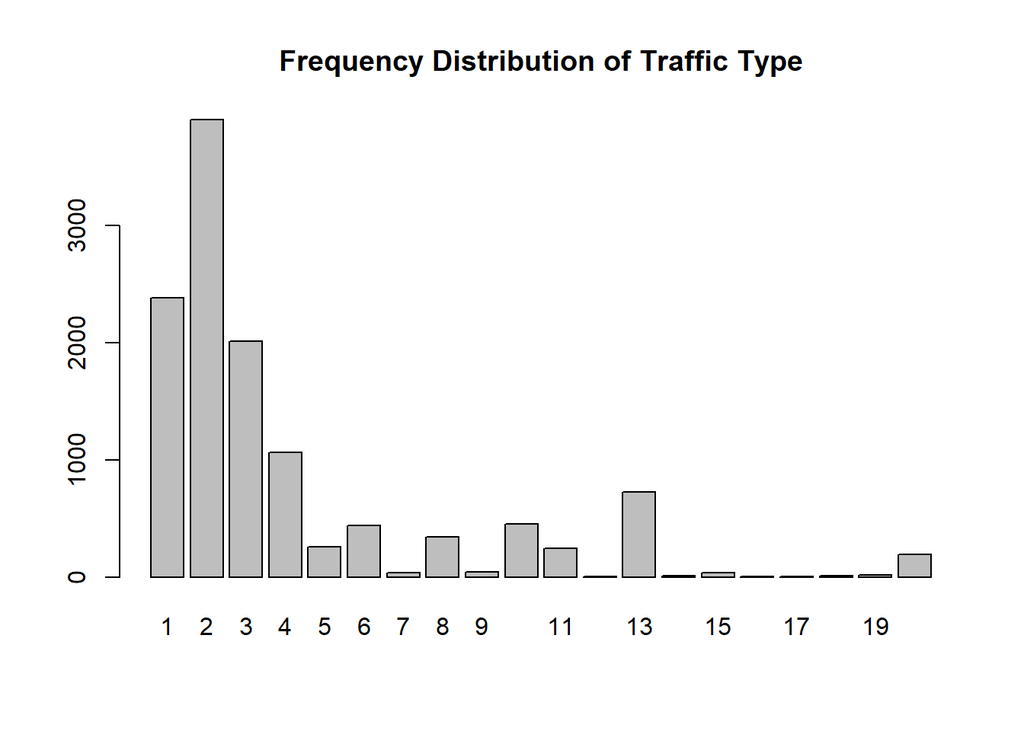

```r
frequency_traffic<-table(df_new$TrafficType)
barplot(frequency_traffic,main = "Frequency Distribution of Traffic Type")
```

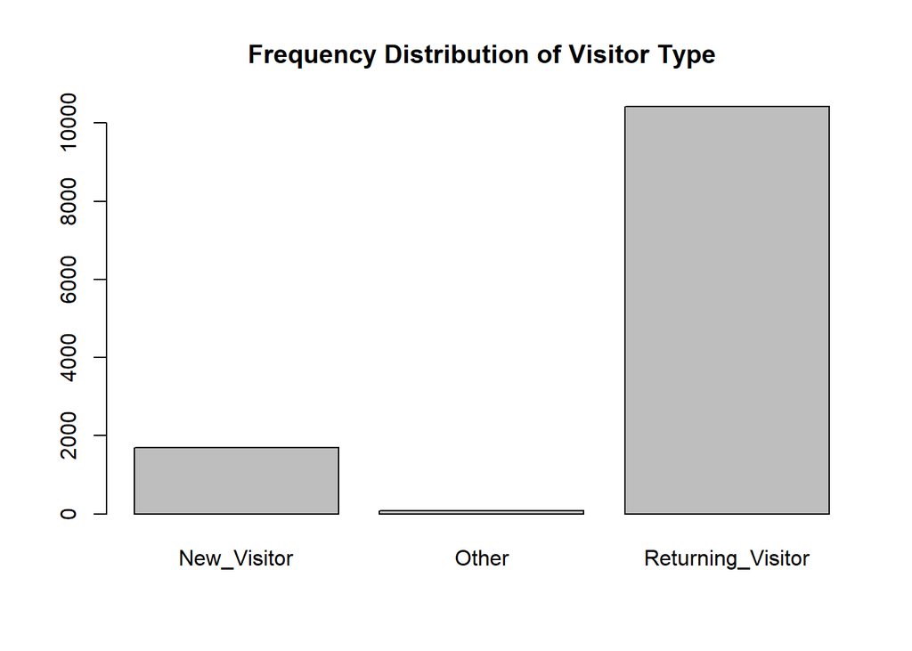

```r
frequency_visitor<-table(df_new$VisitorType)
barplot(frequency_visitor,main="Frequency Distribution of Visitor Type")
```

Most of the visitors were Returning Visitors.

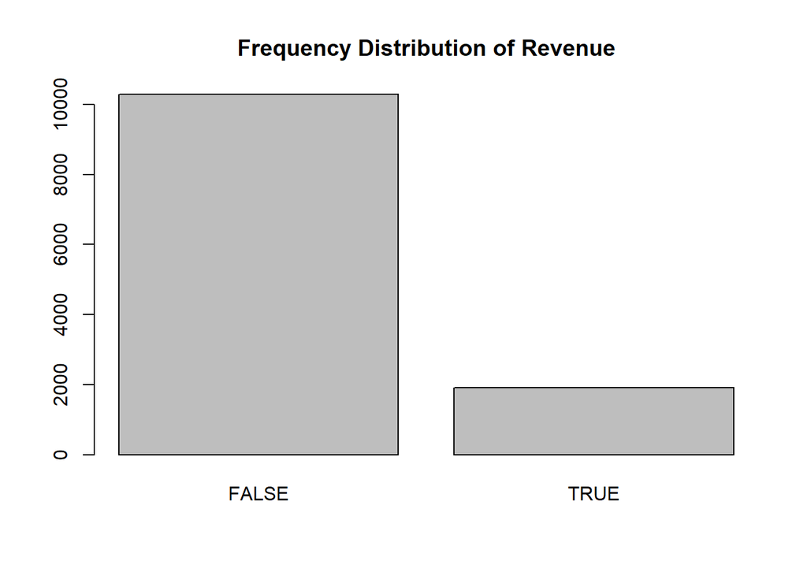

```r
frequency_rev<-table(df_new$Revenue)
barplot(frequency_rev,main="Frequency Distribution of Revenue")
```

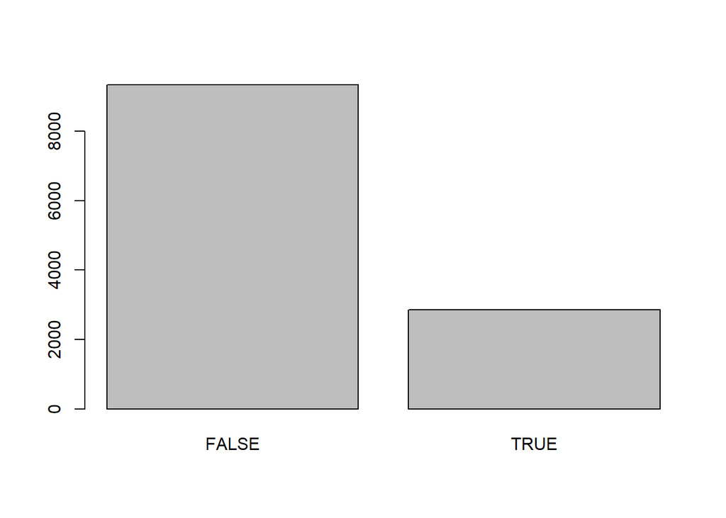

```r
frequency_wkd<-table(df_new$Weekend)
barplot(frequency_wkd)
```

Majority of the respondents visited the site on weekdays.

## Bivariate Analysis

```r
#correlation matrix
cor(df_new[,unlist(lapply(df_new, is.numeric))])
```

```
##                         Administrative Administrative_Duration Informational
## Administrative             1.000000000             0.600409653    0.37528761
## Administrative_Duration    0.600409653             1.000000000    0.30143630
## Informational              0.375287611             0.301436296    1.00000000
## Informational_Duration     0.254786021             0.237189860    0.61867795
## ProductRelated             0.428191515             0.286783914    0.37260472
## ProductRelated_Duration    0.371027224             0.353513793    0.38608372
## BounceRates               -0.213666635            -0.137333397   -0.10950530
## ExitRates                 -0.311274132            -0.202024452   -0.15956681
## PageValues                 0.096920968             0.066168365    0.04739015
## SpecialDay                -0.097072098            -0.074736885   -0.04937677
## OperatingSystems          -0.006697922            -0.007610715   -0.00962587
## Browser                   -0.025763658            -0.015833675   -0.03876681
## Region                    -0.007262053            -0.006723711   -0.03047732
## TrafficType               -0.034784126            -0.015075015   -0.03518669
##                         Informational_Duration ProductRelated
## Administrative                     0.254786021    0.428191515
## Administrative_Duration            0.237189860    0.286783914
## Informational                      0.618677947    0.372604721
## Informational_Duration             1.000000000    0.279061948
## ProductRelated                     0.279061948    1.000000000
## ProductRelated_Duration            0.346580691    0.860308186
## BounceRates                       -0.070159472   -0.193515772
## ExitRates                         -0.102932678   -0.286163211
## PageValues                         0.030064160    0.054115494
## SpecialDay                        -0.031293040   -0.025930622
## OperatingSystems                  -0.009749983    0.004090351
## Browser                           -0.019609349   -0.013706213
## Region                            -0.027920098   -0.040106501
## TrafficType                       -0.025163571   -0.044344333
##                         ProductRelated_Duration  BounceRates    ExitRates
## Administrative                      0.371027224 -0.213666635 -0.311274132
## Administrative_Duration             0.353513793 -0.137333397 -0.202024452
## Informational                       0.386083717 -0.109505298 -0.159566815
## Informational_Duration              0.346580691 -0.070159472 -0.102932678
## ProductRelated                      0.860308186 -0.193515772 -0.286163211
## ProductRelated_Duration             1.000000000 -0.174375499 -0.245334012
## BounceRates                        -0.174375499  1.000000000  0.903358192
## ExitRates                          -0.245334012  0.903358192  1.000000000
## PageValues                          0.050840624 -0.115991977 -0.173571542
```

[output cut: 20 more lines]

```
##                               Region TrafficType
## Administrative          -0.007262053 -0.03478413
## Administrative_Duration -0.006723711 -0.01507502
## Informational           -0.030477323 -0.03518669
## Informational_Duration  -0.027920098 -0.02516357
## ProductRelated          -0.040106501 -0.04434433
## ProductRelated_Duration -0.034862498 -0.03750694
## BounceRates              0.001432015  0.08919904
## ExitRates               -0.001837556  0.08738623
## PageValues               0.010590868  0.01223694
## SpecialDay              -0.016452464  0.05282794
## OperatingSystems         0.071953240  0.18287410
## Browser                  0.091889464  0.10288624
## Region                   1.000000000  0.04252523
## TrafficType              0.042525234  1.00000000
```

# 6.Modelling

### K Means

```r
head(df_new)
```

|  | Administrative | Administrative_Duration | Informational | Informational_Duration | ProductRelated | ProductRelated_Duration | BounceRates | ExitRates | PageValues | SpecialDay | Month | OperatingSystems | Browser | Region | TrafficType | VisitorType | Weekend | Revenue |
| --- | --- | --- | --- | --- | --- | --- | --- | --- | --- | --- | --- | --- | --- | --- | --- | --- | --- | --- |
| 1 | 0 | 0 | 0 | 0 | 1 | 0.000000 | 0.20000000 | 0.2000000 | 0 | 0 | Feb | 1 | 1 | 1 | 1 | Returning_Visitor | FALSE | FALSE |
| 2 | 0 | 0 | 0 | 0 | 2 | 64.000000 | 0.00000000 | 0.1000000 | 0 | 0 | Feb | 2 | 2 | 1 | 2 | Returning_Visitor | FALSE | FALSE |
| 3 | 0 | -1 | 0 | -1 | 1 | -1.000000 | 0.20000000 | 0.2000000 | 0 | 0 | Feb | 4 | 1 | 9 | 3 | Returning_Visitor | FALSE | FALSE |
| 4 | 0 | 0 | 0 | 0 | 2 | 2.666667 | 0.05000000 | 0.1400000 | 0 | 0 | Feb | 3 | 2 | 2 | 4 | Returning_Visitor | FALSE | FALSE |
| 5 | 0 | 0 | 0 | 0 | 10 | 627.500000 | 0.02000000 | 0.0500000 | 0 | 0 | Feb | 3 | 3 | 1 | 4 | Returning_Visitor | TRUE | FALSE |
| 6 | 0 | 0 | 0 | 0 | 19 | 154.216667 | 0.01578947 | 0.0245614 | 0 | 0 | Feb | 2 | 2 | 1 | 3 | Returning_Visitor | FALSE | FALSE |

```r
#transforming the logical variables
df_new$Revenue <- as.numeric(df_new$Revenue)
df_new$Weekend <- as.numeric(df_new$Weekend)
head(df_new)
```

|  | Administrative | Administrative_Duration | Informational | Informational_Duration | ProductRelated | ProductRelated_Duration | BounceRates | ExitRates | PageValues | SpecialDay | Month | OperatingSystems | Browser | Region | TrafficType | VisitorType | Weekend | Revenue |
| --- | --- | --- | --- | --- | --- | --- | --- | --- | --- | --- | --- | --- | --- | --- | --- | --- | --- | --- |
| 1 | 0 | 0 | 0 | 0 | 1 | 0.000000 | 0.20000000 | 0.2000000 | 0 | 0 | Feb | 1 | 1 | 1 | 1 | Returning_Visitor | 0 | 0 |
| 2 | 0 | 0 | 0 | 0 | 2 | 64.000000 | 0.00000000 | 0.1000000 | 0 | 0 | Feb | 2 | 2 | 1 | 2 | Returning_Visitor | 0 | 0 |
| 3 | 0 | -1 | 0 | -1 | 1 | -1.000000 | 0.20000000 | 0.2000000 | 0 | 0 | Feb | 4 | 1 | 9 | 3 | Returning_Visitor | 0 | 0 |
| 4 | 0 | 0 | 0 | 0 | 2 | 2.666667 | 0.05000000 | 0.1400000 | 0 | 0 | Feb | 3 | 2 | 2 | 4 | Returning_Visitor | 0 | 0 |
| 5 | 0 | 0 | 0 | 0 | 10 | 627.500000 | 0.02000000 | 0.0500000 | 0 | 0 | Feb | 3 | 3 | 1 | 4 | Returning_Visitor | 1 | 0 |
| 6 | 0 | 0 | 0 | 0 | 19 | 154.216667 | 0.01578947 | 0.0245614 | 0 | 0 | Feb | 2 | 2 | 1 | 3 | Returning_Visitor | 0 | 0 |

```r
#Label encoding the categorical variables
library(CatEncoders)
encode <- LabelEncoder.fit(df_new$VisitorType)
df_new$VisitorType <- transform(encode,df_new$VisitorType)
encode <- LabelEncoder.fit(df_new$Month)
df_new$Month <- transform(encode,df_new$Month)
print(unique(df_new$Month))
```

```
##  [1]  3  6  7  9  5  4  1  8 10  2
```

```r
print(unique(df_new$VisitorType))
```

```
## [1] 3 1 2
```

```r
#checking if the variables have been encoded
head(df_new)
```

|  | Administrative | Administrative_Duration | Informational | Informational_Duration | ProductRelated | ProductRelated_Duration | BounceRates | ExitRates | PageValues | SpecialDay | Month | OperatingSystems | Browser | Region | TrafficType | VisitorType | Weekend | Revenue |
| --- | --- | --- | --- | --- | --- | --- | --- | --- | --- | --- | --- | --- | --- | --- | --- | --- | --- | --- |
| 1 | 0 | 0 | 0 | 0 | 1 | 0.000000 | 0.20000000 | 0.2000000 | 0 | 0 | 3 | 1 | 1 | 1 | 1 | 3 | 0 | 0 |
| 2 | 0 | 0 | 0 | 0 | 2 | 64.000000 | 0.00000000 | 0.1000000 | 0 | 0 | 3 | 2 | 2 | 1 | 2 | 3 | 0 | 0 |
| 3 | 0 | -1 | 0 | -1 | 1 | -1.000000 | 0.20000000 | 0.2000000 | 0 | 0 | 3 | 4 | 1 | 9 | 3 | 3 | 0 | 0 |
| 4 | 0 | 0 | 0 | 0 | 2 | 2.666667 | 0.05000000 | 0.1400000 | 0 | 0 | 3 | 3 | 2 | 2 | 4 | 3 | 0 | 0 |
| 5 | 0 | 0 | 0 | 0 | 10 | 627.500000 | 0.02000000 | 0.0500000 | 0 | 0 | 3 | 3 | 3 | 1 | 4 | 3 | 1 | 0 |
| 6 | 0 | 0 | 0 | 0 | 19 | 154.216667 | 0.01578947 | 0.0245614 | 0 | 0 | 3 | 2 | 2 | 1 | 3 | 3 | 0 | 0 |

```r
# normalize the dataset
normal <- function(x){
  return ((x-min(x)) / (max(x)-min(x)))
}
df_new$Administrative<- normal(df_new$Administrative)
df_new$Administrative_Duration<- normal(df_new$Administrative_Duration)
df_new$Informational<- normal(df_new$Informational)
df_new$Informational_Duration<- normal(df_new$Informational_Duration)
df_new$ProductRelated<- normal(df_new$ProductRelated)
df_new$ProductRelated_Duration<- normal(df_new$ProductRelated_Duration)
df_new$BounceRates<- normal(df_new$BounceRates)
df_new$ExitRates<- normal(df_new$ExitRates)
df_new$PageValues<- normal(df_new$PageValues)
df_new$SpecialDay<- normal(df_new$SpecialDay)
df_new$OperatingSystems<- normal(df_new$OperatingSystems)
df_new$Browser<- normal(df_new$Browser)
df_new$Region<- normal(df_new$Region)
df_new$TrafficType<- normal(df_new$TrafficType)
head(df_new)
```

|  | Administrative | Administrative_Duration | Informational | Informational_Duration | ProductRelated | ProductRelated_Duration | BounceRates | ExitRates | PageValues | SpecialDay | Month | OperatingSystems | Browser | Region | TrafficType | VisitorType | Weekend | Revenue |
| --- | --- | --- | --- | --- | --- | --- | --- | --- | --- | --- | --- | --- | --- | --- | --- | --- | --- | --- |
| 1 | 0 | 0.0002941393 | 0 | 0.0003920992 | 0.001418440 | 1.563122e-05 | 1.00000000 | 1.000000 | 0 | 0 | 3 | 0.0000000 | 0.00000000 | 0.000 | 0.00000000 | 3 | 0 | 0 |
| 2 | 0 | 0.0002941393 | 0 | 0.0003920992 | 0.002836879 | 1.016029e-03 | 0.00000000 | 0.500000 | 0 | 0 | 3 | 0.1428571 | 0.08333333 | 0.000 | 0.05263158 | 3 | 0 | 0 |
| 3 | 0 | 0.0000000000 | 0 | 0.0000000000 | 0.001418440 | 0.000000e+00 | 1.00000000 | 1.000000 | 0 | 0 | 3 | 0.4285714 | 0.00000000 | 1.000 | 0.10526316 | 3 | 0 | 0 |
| 4 | 0 | 0.0002941393 | 0 | 0.0003920992 | 0.002836879 | 5.731448e-05 | 0.25000000 | 0.700000 | 0 | 0 | 3 | 0.2857143 | 0.08333333 | 0.125 | 0.15789474 | 3 | 0 | 0 |
| 5 | 0 | 0.0002941393 | 0 | 0.0003920992 | 0.014184397 | 9.824223e-03 | 0.10000000 | 0.250000 | 0 | 0 | 3 | 0.2857143 | 0.16666667 | 0.000 | 0.15789474 | 3 | 1 | 0 |
| 6 | 0 | 0.0002941393 | 0 | 0.0003920992 | 0.026950355 | 2.426226e-03 | 0.07894737 | 0.122807 | 0 | 0 | 3 | 0.1428571 | 0.08333333 | 0.000 | 0.10526316 | 3 | 0 | 0 |